# Mapping local authorities to NHS Acute Trusts in England

Sophie Meakin

# Summary

This repo contains a many-to-many mapping between lower-tier local authority districts to NHS Acute Trusts in England, COVID-19 hospital admissions. This mapping can be used to match LTLA-level data, such as testing data, to hospital admissions and other related data that is typically provided at the Trust level.

The mapping contains the following variables:

- `trust_code`: the three-digit organisation code for NHS Trusts.
- `ltla_code`: the nine-digit identifier (LTLA19CD) for lower-tier local authorities in England.
- `p_trust`: the proportion of admissions to a given Trust were admitted from a given LTLA.
- `p_ltla`: the proportion of admissions from a given LTLA that were admitted to a given Trust.

# Usage

The mapping is provided as a `.csv` and `.rds` file. This can be loaded directly with `readRDS()` or `readr::read_csv()`, or using the quick-start functions, outlined below.

## Quick start

Load the quick-start functions with `source("R/quick_start.R")`:

Load the raw mapping with `get_mapping()`:

```r
get_mapping() %>%
  head() %>%
  knitr::kable()
```

| trust_code | ltla_code | p_trust | p_ltla |
| --- | --- | --- | --- |
| R0A | E06000049 | 0.0416667 | 0.0850440 |
| R0A | E08000002 | 0.0086207 | 0.0336134 |
| R0A | E08000003 | 0.5014368 | 0.7678768 |
| R0A | E08000004 | 0.0165230 | 0.0437262 |
| R0A | E08000005 | 0.0086207 | 0.0277136 |
| R0A | E08000006 | 0.0079023 | 0.0246085 |

Add Trust names and lower-tier local authority names to the raw mapping with `get_names()`:

```r
get_names(raw_map = get_mapping()) %>%
  head() %>%
  knitr::kable()
```

| trust_code | trust_name | ltla_code | ltla_name | p_trust | p_ltla |
| --- | --- | --- | --- | --- | --- |
| R0A | Manchester University NHS Foundation Trust | E06000049 | Cheshire East | 0.0416667 | 0.0850440 |
| R0A | Manchester University NHS Foundation Trust | E08000002 | Bury | 0.0086207 | 0.0336134 |
| R0A | Manchester University NHS Foundation Trust | E08000003 | Manchester | 0.5014368 | 0.7678768 |
| R0A | Manchester University NHS Foundation Trust | E08000004 | Oldham | 0.0165230 | 0.0437262 |
| R0A | Manchester University NHS Foundation Trust | E08000005 | Rochdale | 0.0086207 | 0.0277136 |
| R0A | Manchester University NHS Foundation Trust | E08000006 | Salford | 0.0079023 | 0.0246085 |

Summarise the mapping for a given Trust (as defined by the Trust organisation code) with `summarise_mapping()`; this will return a table (under `summary_table`) and a visualisation of the Trust-LTLA mapping (under `summary_plot`):

```r
summary <- summarise_mapping(with_map = get_mapping(), for_trust = "R0A")

summary$summary_table %>%
  knitr::kable()
```

| trust_code | trust_name | ltla_code | ltla_name | p_trust |
| --- | --- | --- | --- | --- |
| R0A | Manchester University NHS Foundation Trust | E08000003 | Manchester | 0.5014368 |
| R0A | Manchester University NHS Foundation Trust | E08000009 | Trafford | 0.3125000 |
| R0A | Manchester University NHS Foundation Trust | E08000007 | Stockport | 0.0732759 |
| R0A | Manchester University NHS Foundation Trust | E06000049 | Cheshire East | 0.0416667 |
| R0A | Manchester University NHS Foundation Trust | E08000008 | Tameside | 0.0294540 |
| R0A | Manchester University NHS Foundation Trust | E08000004 | Oldham | 0.0165230 |
| R0A | Manchester University NHS Foundation Trust | E08000002 | Bury | 0.0086207 |
| R0A | Manchester University NHS Foundation Trust | E08000005 | Rochdale | 0.0086207 |
| R0A | Manchester University NHS Foundation Trust | E08000006 | Salford | 0.0079023 |

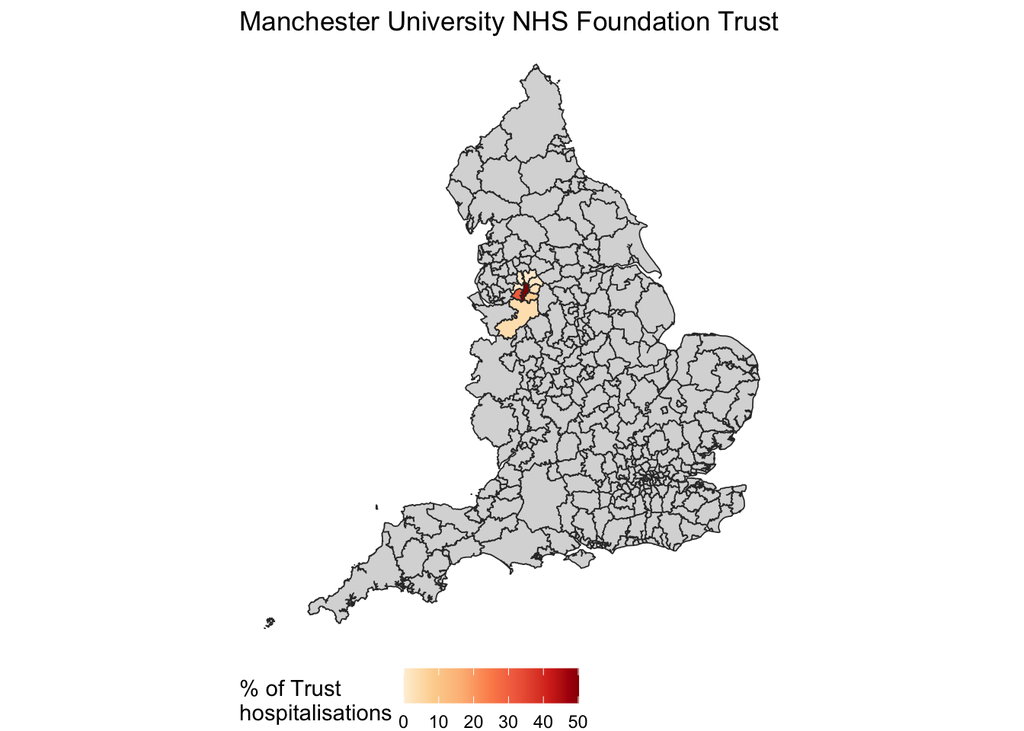

```r
summary$summary_plot
```

Summarise the mapping for a given LTLA (as defined by the LTLA organisation code) with `summarise_mapping()`; this will return a table (under `summary_table`):

```r
summary <- summarise_mapping(with_map = get_mapping(), for_ltla = "E09000012")

summary$summary_table %>%
  knitr::kable()
```

| ltla_code | ltla_name | trust_code | trust_name | p_ltla |
| --- | --- | --- | --- | --- |
| E09000012 | Hackney | RQX | Homerton University Hospital NHS Foundation Trust | 0.6753472 |
| E09000012 | Hackney | R1H | Barts Health NHS Trust | 0.2135417 |
| E09000012 | Hackney | RRV | University College London Hospitals NHS Foundation Trust | 0.0677083 |
| E09000012 | Hackney | RKE | Whittington Health NHS Trust | 0.0434028 |

# Methods

The raw (unpublished) mapping was provided by NHS England, This mapping provides the number of COVID-19 spells (discharges) between 01 January 2020 and 30 September 2020 by hospital-LTLA pairs, based on the Secondary Uses Service (SUS) healthcare data for England.

We have summarised the raw mapping to Trust-LTLA (rather than hospital-LTLA) pairs, and to maintain anonymity we excluded any pair where the number of spells is less than 10. Finally, we report only the proprtion of admissions by Trust (`p_trust`) or LTLA (`p_ltla`).